# CFRM 502, Winter 2020

# Instructor: Bahman Angoshtari

# Lecture 14

**Chapter 15:** vector error correction (VEC) models, Johansen's cointegration test

**Chapter 18:** principal component analysis (PCA)

```r
# Setting parameters of the Jupyter notebook
sc = .75
options(repr.plot.width=16*sc,
        repr.plot.height=7*sc,
        repr.plot.pointsize = 13, # Text height in pt
        repr.plot.bg        = 'white',
        repr.plot.antialias = 'gray',
        #nice medium-res DPI
        repr.plot.res       = 300,
        #jpeg quality bumped from default
        repr.plot.quality   = 90,
        #vector font family
        repr.plot.family    = 'serif')
# Vector font family. 'sans', 'serif', 'mono' or a specific one
```

$\newcommand{\1}{{\bf 1}}$ $\newcommand{\0}{{\bf 0}}$ $\newcommand\Fc{\mathscr{F}}$ $\newcommand{\eps}{\varepsilon}$ $\newcommand{\Var}{\operatorname{Var}}$ $\newcommand{\diag}{\operatorname{diag}}$ $\newcommand{\vec}{\operatorname{vec}}$ $\newcommand{\det}{\operatorname{det}}$ $\newcommand\Cov{\operatorname{Cov}}$ $\newcommand\Corr{\operatorname{Corr}}$ $\newcommand{\sig}{\sigma}$ $\newcommand\Sig{\Sigma}$ $\newcommand{\al}{\alpha}$ $\newcommand{\gam}{\gamma}$ $\newcommand\Gam{\Gamma}$ $\newcommand\lam{\lambda}$ $\newcommand{\Del}{\Delta}$ $\newcommand{\del}{\delta}$ $\newcommand\tht{\theta}$ $\newcommand\ph{\varphi}$ $\newcommand\om{\omega}$ $\newcommand\Om{\Omega}$ $\newcommand\rb{\bar{r}}$ $\newcommand{\Xb}{\bar{X}}$ $\newcommand{\Yb}{\bar{Y}}$ $\newcommand\Eb{\mathbb{E}}$ $\newcommand\Pb{\mathbb{P}}$ $\newcommand\Qb{\mathbb{Q}}$ $\newcommand\Rb{\mathbb{R}}$ $\newcommand\Zb{\mathbb{Z}}$ $\newcommand\Nb{\mathbb{N}}$ $\newcommand\Av{\textbf{A}}$ $\newcommand\av{\mathbf{a}}$ $\newcommand\Bv{\textbf{B}}$ $\newcommand\bv{\mathbf{b}}$ $\newcommand\Ev{\textbf{E}}$ $\newcommand\Dv{\textbf{D}}$ $\newcommand\Fv{\textbf{F}}$ $\newcommand\Gv{\textbf{G}}$ $\newcommand\Hv{\textbf{H}}$ $\newcommand\Kv{\textbf{K}}$ $\newcommand\Iv{\textbf{I}}$ $\newcommand\Pv{\textbf{P}}$ $\newcommand\Ov{\textbf{O}}$ $\newcommand\Sv{\textbf{S}}$ $\newcommand\Xv{\textbf{X}}$ $\newcommand\Yv{\textbf{Y}}$ $\newcommand\Zv{\textbf{Z}}$ $\newcommand\xv{\mathbf{x}}$ $\newcommand\yv{\mathbf{y}}$ $\newcommand\zv{\mathbf{z}}$ $\newcommand\Cv{\mathbf{C}}$ $\newcommand\mv{\mathbf{m}}$ $\newcommand\nv{\mathbf{n}}$ $\newcommand\pv{\mathbf{p}}$ $\newcommand\rv{\mathbf{r}}$ $\newcommand\sv{\mathbf{s}}$ $\newcommand\wv{\mathbf{w}}$ $\newcommand\Wv{\textbf{W}}$ $\newcommand\alv{{\boldsymbol\al}}$ $\newcommand\betav{{\boldsymbol\beta}}$ $\newcommand\etav{{\boldsymbol\eta}}$ $\newcommand\epsv{{\boldsymbol\varepsilon}}$ $\newcommand\delv{{\boldsymbol\delta}}$ $\newcommand\Lamv{{\boldsymbol\Lambda}}$ $\newcommand\lamv{{\boldsymbol\lambda}}$ $\newcommand\muv{{\boldsymbol\mu}}$ $\newcommand\piv{{\boldsymbol\pi}}$ $\newcommand\Piv{{\boldsymbol\Pi}}$ $\newcommand\Gamv{{\boldsymbol\Gam}}$ $\newcommand\Phiv{{\boldsymbol\Phi}}$ $\newcommand\rhov{\boldsymbol{\rho}}$ $\newcommand\Sigv{{\boldsymbol\Sig}}$ $\newcommand\ah{\widehat{a}}$ $\newcommand\Pbh{\widehat{\Pb}}$ $\newcommand\phh{\widehat{\varphi}}$ $\newcommand\Ebh{\widehat{\Eb}}$ $\newcommand\Qh{\widehat{Q}}$ $\newcommand\Ih{\widehat{I}}$ $\newcommand\rh{\widehat{r}}$ $\newcommand\pih{\widehat{\pi}}$ $\newcommand\Pih{\widehat{\Pi}}$ $\newcommand\Sigvh{\widehat{\Sigv}}$ $\newcommand\Wh{\widehat{W}}$ $\newcommand\Fh{\widehat{F}}$ $\newcommand\Yh{\widehat{Y}}$ $\newcommand\Zh{\widehat{Z}}$ $\newcommand\Yvh{\widehat{\Yv}}$ $\newcommand\Ah{\widehat{\Ac}}$ $\newcommand\uh{\widehat{u}}$ $\newcommand\vh{\widehat{v}}$ $\newcommand\fh{\widehat{f}}$ $\newcommand\hh{\widehat{h}}$ $\newcommand\Bh{\widehat{B}}$ $\newcommand\Ovh{\widehat{\Ov}}$ $\newcommand\Xvh{\widehat{\Xv}}$ $\newcommand\rhoh{\widehat{\rho}}$ $\newcommand\omh{\widehat{\om}}$ $\newcommand\nuh{\widehat{\nu}}$ $\newcommand\varphih{\widehat{\varphi}}$ $\newcommand\alh{\widehat{\al}}$ $\newcommand\thetah{\widehat{\theta}}$ $\newcommand\betah{\widehat{\beta}}$ $\newcommand\betavh{\widehat{\boldsymbol\beta}}$ $\newcommand\kaph{\widehat{\kappa}}$ $\newcommand\sigh{\widehat{\sigma}}$ $\newcommand\epsh{\widehat{\eps}}$ $\newcommand\epsvh{\widehat{\epsv}}$ $\newcommand\epst{\widetilde{\eps}}$ $\newcommand\muh{\widehat{\mu}}$ $\newcommand\dd{\mathrm{d}}$ $\newcommand\ee{\mathrm{e}}$

# 0. Overview of the lecture

- In this lecture, we consider the vector error correction (VEC) model. It is the main way of modeling high-dimensional cointegrated time series. We also learn the Johansen cointegration test which is based on VEC model.
- We then discuss **principal component analysis (PCA)**. This is a dimension reduction technique that was originally developed for independent Gaussian samples, but has become a very useful tool for multivariate time series analysis (and other high dimensional statistical problems)

# 1. Motivation through the two-step method

- Recall the definition of cointegration from Lecture 13:
- **Definition:**

  Processes $\{Y_{t,1}\}, \dots, \{Y_{t,k}\}$ are **"cointegrated"** if:

  **(i)** They are non-stationary; and,

  **(ii)** There is at least one linear combination $Z_t = \beta_1 Y_{t,1} + \dots + \beta_n Y_{t,k}$ that is stationary
- In such cases, $\{Z_t\}$ is called a **"cointegrating relationship"** and $(\beta_1,\dots,\beta_n)$ is called a **"cointegrating vector"**
- We have discussed the **two-step procedure** for cointegration analysis
- Consider time series $\{Y_{t,1}\}, \dots, \{Y_{t,n}\}$
- **Step 1:** Regress $\{Y_{1,t}\}$ on the remaining time series: $Y_{t,1} = \beta_0 + \beta_2 Y_{t,2} + \dots + \beta_n Y_{t,n} + Z_t$ Let $\{\Zh_t\}$ be the residual of this regression
- **Step 2:** Test if $\{\Zh_t\}$ is stationary.
  - For this step, use unit root test that are designed for the two-step method, such as the Phillips-Ouliaris test (alternative hypothesis is cointegration)
  - If the test indicates cointegration, then $\{\Zh_t\}$ is the cointegrating relation and $(1,-\beta_2,\dots,-\beta_n)$ is a cointegrating vector

## 1.1. A 5-dimensional example

- In the previous lecture, we have seen the two step approach in a bivariate example (MSFT-IBM prices)
- Let us consider a higher dimensional example
- Since linear combination of stationary time series is stationary, if we have $k$ time series, we can have up to $k-1$ **linearly independent** cointegrating vector
- In particular, note that if $k$ time series have $k$ stationary **linearly independent** combination, then they must be individually stationary. Hence, we cannot have more then $k-1$ **linearly independent** cointegrating vector.
- Note, that linear independence is crucial in this statement.
- Any linear combination of two cointegrating relationship is still stationary, and hence, a cointegrating relationship
- So, if there is at least 1 cointegrating relationship, we can find infinitely many other cointegrating relationship, which will be however not necessarily linearly independent
- Why linear independence is important? Think about cointegrating relationship as portfolios. What is a linear combination of two portfolios?
- Consider an example with 5 time series, namely, the daily values of treasury yield (i.e. the interest rate) for 5 different maturity

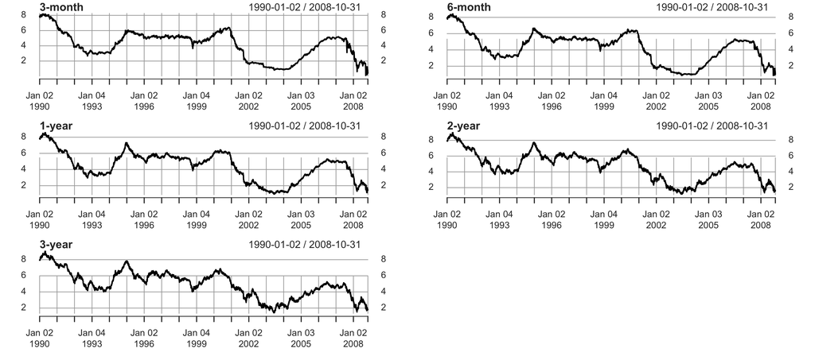

```r
library("xts")
yieldDat = read.table("treasury_yields.txt",header=T)
date = as.Date(yieldDat[,1], format = "%m/%d/%y")
dat = as.xts(yieldDat[,3:7], date)
par(mfrow=c(3,2));par(mar=c(4,4,4,4))
plot(dat[,1],type="l",ylab="",main="3-month", minor.tick=FALSE)
plot(dat[,2],type="l",ylab="",main="6-month", minor.tick=FALSE)
plot(dat[,3],type="l",ylab="",main="1-year", minor.tick=FALSE)
plot(dat[,4],type="l",ylab="",main="2-year", minor.tick=FALSE)
plot(dat[,5],type="l",ylab="",main="3-year", minor.tick=FALSE)
```

- Before we begin, we should check that the treasury yields are not stationary. This is clear from the time series plots. Alternatively, we can run KPSS test

```r
library(tseries)
kpss.test(dat[,1])
kpss.test(dat[,2])
kpss.test(dat[,3])
kpss.test(dat[,4])
kpss.test(dat[,5])
```

```
	KPSS Test for Level Stationarity

data:  dat[, 1]
KPSS Level = 13.202, Truncation lag parameter = 10, p-value = 0.01
```

```
	KPSS Test for Level Stationarity

data:  dat[, 2]
KPSS Level = 13.329, Truncation lag parameter = 10, p-value = 0.01
```

```
	KPSS Test for Level Stationarity

data:  dat[, 3]
KPSS Level = 15.158, Truncation lag parameter = 10, p-value = 0.01
```

```
	KPSS Test for Level Stationarity

data:  dat[, 4]
KPSS Level = 19.982, Truncation lag parameter = 10, p-value = 0.01
```

```
	KPSS Test for Level Stationarity

data:  dat[, 5]
KPSS Level = 23.196, Truncation lag parameter = 10, p-value = 0.01
```

- There are 5 time series, so, we can have up to 4 cointegrating relationship.
- Let us use the two-step approach to find one cointegrating relationship.
- The `ca.po()` function uses the first column of data as the response variable in the regression of Step 1 of the two-step method.

```r
dat_3mo_first=dat
head(dat_3mo_first)
```

```
           X3mo X6mo X1yr X2yr X3yr
1990-01-02 7.83 7.89 7.81 7.87 7.90
1990-01-03 7.89 7.94 7.85 7.94 7.96
1990-01-04 7.84 7.90 7.82 7.92 7.93
1990-01-05 7.79 7.85 7.79 7.90 7.94
1990-01-08 7.79 7.88 7.81 7.90 7.95
1990-01-09 7.80 7.82 7.78 7.91 7.94
```

- The Phillips-Ouliaris test stat is 408, which is much larger that the 1% critical value of 71.5214. So, we find the following cointegrating relationship

\begin{align*} &\text{X3mo}_t = -0.150672 +1.674594 \,\text{X6mo}_t -0.635539\,\text{X1yr}_t -0.457234\,\text{X2yr}_t +0.420949 \,\text{X3yr}_t + Z_{t,1}\\\\ &\Longrightarrow\qquad Z_{t,1} = 0.150672 + \text{X3mo}_t - 1.674594\, \text{X6mo}_t + 0.635539\,\text{X1yr}_t + 0.457234\,\text{X2yr}_t - 0.420949 \,\text{X3yr}_t \end{align*}

```r
library(urca)
coint_po_3mo = ca.po(dat_3mo_first, demean="constant")
summary(coint_po_3mo)
```

```
########################################
# Phillips and Ouliaris Unit Root Test #
########################################

Test of type Pu
detrending of series with constant only


Call:
lm(formula = z[, 1] ~ z[, -1])

Residuals:
     Min       1Q   Median       3Q      Max
-0.95945 -0.05311  0.00760  0.06757  0.38542

Coefficients:
             Estimate Std. Error t value Pr(>|t|)
(Intercept) -0.150672   0.006815  -22.11   <2e-16 ***
z[, -1]X6mo  1.674594   0.012648  132.40   <2e-16 ***
z[, -1]X1yr -0.635539   0.022000  -28.89   <2e-16 ***
z[, -1]X2yr -0.457234   0.030511  -14.99   <2e-16 ***
z[, -1]X3yr  0.420949   0.019803   21.26   <2e-16 ***
---
Signif. codes:  0 ‘***’ 0.001 ‘**’ 0.01 ‘*’ 0.05 ‘.’ 0.1 ‘ ’ 1

Residual standard error: 0.1036 on 4709 degrees of freedom
Multiple R-squared:  0.9967,	Adjusted R-squared:  0.9967
F-statistic: 3.508e+05 on 4 and 4709 DF,  p-value: < 2.2e-16


Value of test-statistic is: 408.8865

Critical values of Pu are:
                  10pct    5pct    1pct
critical values 45.3308 53.2502 71.5214
```

- As we said, there are up to 4 cointegrating relationship in 5 time series. So, there may be 3 other cointegrating relationships.
- How can we find other relationships with the two-step approach?
- We may try changing the response variable in the regression of Step 1.
- When using the `ca.po()` function, simply flip the first column with another column

```r
dat_6mo_first=cbind(dat[,2],dat[,-2])
head(dat_6mo_first)
```

```
           X6mo X3mo X1yr X2yr X3yr
1990-01-02 7.89 7.83 7.81 7.87 7.90
1990-01-03 7.94 7.89 7.85 7.94 7.96
1990-01-04 7.90 7.84 7.82 7.92 7.93
1990-01-05 7.85 7.79 7.79 7.90 7.94
1990-01-08 7.88 7.79 7.81 7.90 7.95
1990-01-09 7.82 7.80 7.78 7.91 7.94
```

- The Phillips-Ouliaris test stat is 521.8725, which is much larger that the 1% critical value of 71.5214. So, we find the following cointegrating relationship

\begin{align*} &\text{X6mo}_t = 0.072350 +0.470711 \,\text{X3mo}_t + 0.611375\,\text{X1yr}_t + 0.109360\,\text{X2yr}_t - 0.192420 \,\text{X3yr}_t + Z_{t,1}\\\\ &\Longrightarrow\qquad Z_{t,1} = -0.072350 - 0.470711\, \text{X3mo}_t + \text{X3mo}_t - 0.611375\,\text{X1yr}_t - 0.109360\,\text{X2yr}_t + 0.192420 \,\text{X3yr}_t \end{align*}

```r
coint_po_6mo = ca.po(dat_6mo_first, demean="constant")
summary(coint_po_6mo)
```

```
########################################
# Phillips and Ouliaris Unit Root Test #
########################################

Test of type Pu
detrending of series with constant only


Call:
lm(formula = z[, 1] ~ z[, -1])

Residuals:
     Min       1Q   Median       3Q      Max
-0.19955 -0.03345 -0.00282  0.03139  0.44859

Coefficients:
             Estimate Std. Error t value Pr(>|t|)
(Intercept)  0.072350   0.003647  19.839  < 2e-16 ***
z[, -1]X3mo  0.470711   0.003555 132.399  < 2e-16 ***
z[, -1]X1yr  0.611375   0.008988  68.024  < 2e-16 ***
z[, -1]X2yr  0.109360   0.016481   6.636 3.59e-11 ***
z[, -1]X3yr -0.192420   0.010628 -18.105  < 2e-16 ***
---
Signif. codes:  0 ‘***’ 0.001 ‘**’ 0.01 ‘*’ 0.05 ‘.’ 0.1 ‘ ’ 1

Residual standard error: 0.05491 on 4709 degrees of freedom
Multiple R-squared:  0.9991,	Adjusted R-squared:  0.9991
F-statistic: 1.261e+06 on 4 and 4709 DF,  p-value: < 2.2e-16


Value of test-statistic is: 521.8725

Critical values of Pu are:
                  10pct    5pct    1pct
critical values 45.3308 53.2502 71.5214
```

- We can use any of the five time series as the response variable in Step 1.
- Let us see if these will result in new cointegrating relationship.
- Note that we only need the Phillips-Ouliaris test stat and compare it with the critical value of 71.5214

```r
coint_po_3mo@teststat
coint_po_6mo@teststat
```

408.886536343019

521.872513486413

```r
ca.po(cbind(dat[,3],dat[,-3]), demean="constant")@teststat
ca.po(cbind(dat[,4],dat[,-4]), demean="constant")@teststat
ca.po(cbind(dat[,5],dat[,-5]), demean="constant")@teststat
```

268.548026562874

308.956028412442

174.398926448367

- Apparently, we found 5 cointegrating relationships.
- But, we have already checked that the 5 time series are not stationary. So, we cannot have 5 cointegrating relationships!
- Is this a contradiction?
- No, because there is no guarantee that the linear combinations are independent! (check this)
- This is the main shortcoming of the two-step method. At its core, it is a univariate method as it can only find one cointegrating relationship at a time.
- To properly find cointegrating relationships, we have to consider a multivariate approach.

# 2. Vector Error Correction (VEC) models and Johansen's approach

- As we illustrated, the two step approach for identifying cointegrated processes is not suitable for dimensions larger than 2
- The choice of regression model becomes rather arbitrary. Also, there might be more than 1 cointegrating relationship
- The corresponding unit-root tests (e.g. Phillips-Ouliaris test) is not applicable for high dimensions (the distribution of the test statistic is not available.)
- A more systematic approach is to consider a **VEC model**
- Consider the following model:

\begin{align}\tag{$\star$} \begin{cases} \Del Y_{1,t} = \eta_1 Z_{t-1} + \eps_{1,t}\\ \Del Y_{2,t} = \eta_2 Z_{t-1} + \eps_{2,t}\\ Z_{t} = Y_{1,t} - c Y_{2,t} \end{cases} \end{align}

- Here, $c$, $\eta_1$, and $\eta_2$ are constants and $\{(\eps_{1,t},\eps_{2,t})\}$ is a weak WN
- As shown in the example in Section 3 of Lecture 13, we have $Z_t = (1+\eta_1-c\,\eta_2) Z_{t-1} + \eps_{3,t}$, where $\eps_{3,t} :=\eps_{1,t}-c\,\eps_{2,t}$ is a weak WN
- If $-2<\eta_1-c\,\eta_2<0$, then $Z_t$ is a stationary AR(1) process. Thus, $(Y_{1,t}, Y_{2,t})$ is I(1) and cointegrated
- Note that for $-2<\eta_1-c\,\eta_2<0$, any deviation of $Z_{t-1}$ from 0 (its stationary mean) is *"corrected"* in step $t$. For this reason, $(\star)$ is called a Vector Error Correction (VEC) model
- We can can generalize $(\star)$ for n-dimensional processes $\Yv_t = (Y_{1,t},\dots,Y_{n,t})^\top$

\begin{align*} \Del \Yv_t = \alv\,\betav^\top \Yv_{t-1} + \eps_v = \begin{pmatrix} \al_{1,1} &\dots &\al_{1,r}\\ \vdots &\ddots &\vdots\\ \al_{n,1} &\dots &\al_{n,r} \end{pmatrix}\, \begin{pmatrix}\beta_{1,1} &\dots &\beta_{1,r}\\ \vdots &\ddots &\vdots\\ \beta_{n,1} &\dots &\beta_{n,r} \end{pmatrix}^\top \begin{pmatrix} Y_{1,t-1}\\ \vdots\\ Y_{n,t-1} \end{pmatrix} + \begin{pmatrix} \eps_{1,t}\\ \vdots\\ \eps_{n,t} \end{pmatrix} \end{align*}

- Here, the **"cointegration rank"** $r\in\{1,\dots,n-1\}$ is the number of cointegrating relationship, and $\alv$ and $\betav$ are $n\times r$ matrices of rank $r$
- Columns of $\betav$ are the cointegrating vectors and $\alv$ is called the **"loading matrix"**
- Note that for the matrix $\Piv := \alv\,\betav^\top$, we have rank$(\Piv) = r$
- In Johansen's approach, one considers fitting a more general VEC model

\begin{align*} \Del \Yv_t = \underbrace{\Piv\,\Yv_{t-1}}_{\text{VEC term}}+\underbrace{\Gamv_1 \Del \Yv_{t-1} + \dots + \Gamv_{p-1} \Del \Yv_{t-p+1}}_{\text{VAR terms}} + \underbrace{\muv + \Phiv\, \Dv_t}_{\text{deterministic trend}} + \epsv_t \end{align*}

- To identify the cointegration rank $r$, one conducts a sequence of statistical test for the rank of $\Piv$, that is, $H_0: \text{rank}(\Piv)\le r$ versus $H_1: \text{rank}(\Piv)>r$
- The cointegration rank is the value of $r$ for which $H_0: \text{rank}(\Piv)\le r-1$ is rejected but $H_0: \text{rank}(\Piv)\le r$ is accepted
- In particular, if $H_0:\text{rank}(\Piv)\le n-1$ is rejected, then $\{\Yv_t\}$ is I(0) (i.e. all $\{Y_{i,t}\}$, $i\in\{1,\dots,n\}$, are weakly stationary)
- If $H_0:\text{rank}(\Piv)\le 0$ is accepted, then there is no cointegrating relationship, and $\{\Yv_t\}$ is only an I(1) process
- Let us illustrate Johansen's approach using the Microsoft / IBM pair

1. 'MSFT'

2. 'IBM'

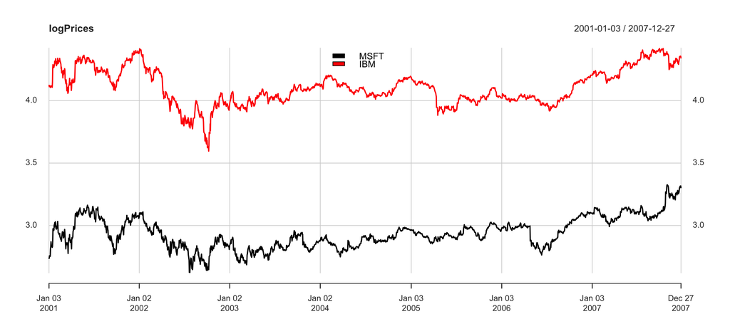

```r
library("quantmod")
getSymbols(c("MSFT", "IBM"), from="2001-01-03", to="2007-12-28", src="yahoo")
logPrices = log(na.omit(merge(MSFT$MSFT.Adjusted,IBM$IBM.Adjusted)))
names(logPrices) = c("MSFT", "IBM")
plot(logPrices, legend.loc='top', major.ticks = "years",
     grid.ticks.on = "years", grid.col = "lightgray")
```

- We can use the `ca.jo()` function of the `urca` package to perform Johansen's test

```r
summary(ca.jo(logPrices))
```

```
######################
# Johansen-Procedure #
######################

Test type: maximal eigenvalue statistic (lambda max) , with linear trend

Eigenvalues (lambda):
[1] 0.007434006 0.002522375

Values of teststatistic and critical values of test:

          test 10pct  5pct  1pct
r <= 1 |  4.43  6.50  8.18 11.65
r = 0  | 13.08 12.91 14.90 19.19

Eigenvectors, normalised to first column:
(These are the cointegration relations)

           MSFT.l2   IBM.l2
MSFT.l2  1.0000000 1.000000
IBM.l2  -0.7614675 2.042816

Weights W:
(This is the loading matrix)

            MSFT.l2       IBM.l2
MSFT.d -0.010331711 -0.001973605
IBM.d   0.006829422 -0.001934014
```

- Look at the table titled "Values of teststatistic and critical values of test:"
  - Test stat for $H_0: r=0$ is 13.08, larger than the 10% critical value of 12.91. So, we reject that $r=0$ under 10% level
  - Test stat for $H_1: r\le 1$ is 4.43, smaller than the 10% critical value of 6.5. So, we accept that $r\le 1$ under 10%.
- Therefore, $r=1$ under 10% significance. There is exactly 1 cointegrating relationship.
- What conclusion you get under 5% level?
- To find a cointegrating vector, we look at the table titled "Eigenvectors, normalised to first column:(These are the cointegration relations)"
- Since $r=1$, we look at the first (leftmost) column, i.e. $(1, -0.7614675)$. This indicates the cointegration relationship $Z_t = \log \text{MSFT}_t -0.7614675 \log \text{IBM}_t$
- Let $p_{1,t}$ $ =$ $ \log$ MSFT$_t$ and $p_{2,t}$ $ = $ $ \log$ IBM$_t$
- The fitted error correction model is

\begin{align*} \begin{pmatrix}\Del\,p_{1,t}\\ \Del\,p_{2,t}\end{pmatrix}=\begin{pmatrix}-0.010331711\\ 0.006829422\end{pmatrix} \begin{pmatrix}1\\-0.7614675\end{pmatrix}^\top\begin{pmatrix} p_{1,t-1}\\ p_{2,t-1}\end{pmatrix}+ \begin{pmatrix}\eps_{1,t}\\\eps_{2,t}\end{pmatrix} \end{align*}

- Next, consider an example with 5 time series, namely, the daily values of treasury yield (i.e. the interest rate) for 5 different maturity

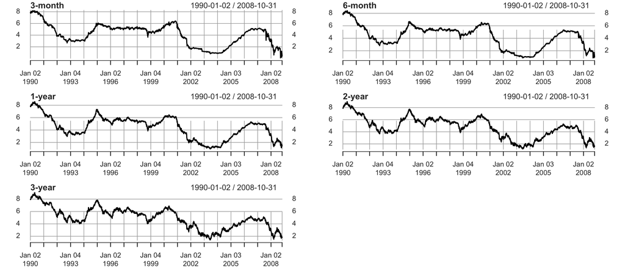

```r
par(mfrow=c(3,2));par(mar=c(4,4,4,4))
plot(dat[,1],type="l",ylab="",main="3-month", minor.tick=FALSE)
plot(dat[,2],type="l",ylab="",main="6-month", minor.tick=FALSE)
plot(dat[,3],type="l",ylab="",main="1-year", minor.tick=FALSE)
plot(dat[,4],type="l",ylab="",main="2-year", minor.tick=FALSE)
plot(dat[,5],type="l",ylab="",main="3-year", minor.tick=FALSE)
```

```r
summary(ca.jo(dat))
```

```
######################
# Johansen-Procedure #
######################

Test type: maximal eigenvalue statistic (lambda max) , with linear trend

Eigenvalues (lambda):
[1] 0.0343599115 0.0237709602 0.0146978801 0.0014047190 0.0005504632

Values of teststatistic and critical values of test:

           test 10pct  5pct  1pct
r <= 4 |   2.59  6.50  8.18 11.65
r <= 3 |   6.62 12.91 14.90 19.19
r <= 2 |  69.77 18.90 21.07 25.75
r <= 1 | 113.36 24.78 27.14 32.14
r = 0  | 164.75 30.84 33.32 38.78

Eigenvectors, normalised to first column:
(These are the cointegration relations)

           X3mo.l2    X6mo.l2   X1yr.l2     X2yr.l2    X3yr.l2
X3mo.l2  1.0000000   1.000000  1.000000  1.00000000  1.0000000
X6mo.l2 -1.9514244   2.463236  1.073534  0.05915024  0.8974944
X1yr.l2  1.0564695  14.250135 -3.949741 -2.54331844 -1.5849870
X2yr.l2  0.3041617 -46.533959  3.509348 -3.47738127 -0.1182572
X3yr.l2 -0.4116065  30.124547 -1.713694  5.23224147  1.9378469

Weights W:
(This is the loading matrix)

            X3mo.l2       X6mo.l2       X1yr.l2       X2yr.l2       X3yr.l2
X3mo.d -0.034412220 -0.0024403334 -0.0115279795 -1.783178e-04 -0.0001042302
X6mo.d  0.015956671 -0.0020898399 -0.0070663158  2.667428e-04 -0.0001699733
X1yr.d -0.005848926 -0.0016611489 -0.0012554616  3.575079e-04 -0.0002888574
X2yr.d  0.005853760 -0.0005792231 -0.0036731258 -7.206161e-05 -0.0004118552
X3yr.d  0.012082416 -0.0009848982 -0.0002165113 -4.312634e-04 -0.0004072168
```

\begin{align*} \begin{pmatrix}\Del\,r_{1,t}\\ \Del\,r_{2,t}\\ \Del\,r_{3,t}\\ \Del\,r_{4,t}\\ \Del\,r_{5,t}\end{pmatrix}= \begin{pmatrix}-0.034412220 & -0.0024403334 & -0.0115279795\\ 0.015956671 & -0.0020898399 & -0.0070663158\\ -0.005848926 & -0.0016611489 & -0.0012554616\\ 0.005853760 & -0.0005792231 & -0.0036731258\\ 0.012082416 & -0.0009848982 & -0.0002165113 \end{pmatrix} \begin{pmatrix}1.0000000 & 1.000000 & 1.000000\\-1.9514244 & 2.463236 & 1.073534\\1.0564695 &14.250135 &-3.949741\\0.3041617 &-46.533959 & 3.509348\\-0.4116065& 30.124547& -1.713694\end{pmatrix}^\top\begin{pmatrix}r_{1,t-1}\\ r_{2,t-1}\\ r_{3,t-1}\\ r_{4,t-1}\\ r_{5,t-1}\end{pmatrix} + \begin{pmatrix}\eps_{1,t}\\ \eps_{2,t} \\ \eps_{3,t}\\ \eps_{4,t}\\ \eps_{5,t}\end{pmatrix} \end{align*}

# 3. Eigendecomposition

- Analyzing multivariate time series can be very challenging, in particular when the number of time series is large. Many time series, however, exhibit similar characteristics such as common trends or seasonality.
- The main approach to high dimensional time series analysis is to express a large number of times series in terms of a small number of time series or **factors**. This approach is usually referred to as **dimension reduction**
- In most dimension reduction problems, the factors are not known and should be inferred from the observations. Principal component analysis (PCA) is one such approach.
- Suppose that we are given a sample of T independent and identically distributed observations $\{\Yv_{t} = (Y_{t,1},\dots, Y_{t,k})\}_{t=1}^T$
- Our task goal is to **explain** the variations in the values of $\Yv_t$ with a smaller number of variables, say $\{\Xv_{t} = (X_{t,1},\dots, X_{t,m})\}_{t=1}^T$, where $m\ll k$ ($m$ is much smaller than $k$).
- PCA can find the **best** set of such $\{\Xv_t\}$ as well $m$
- We need a few concept from linear algebra
- Let $\Sigv$ be an $n\times n$ matrix. Assume that there is a non-zero vector $e\in\Rb^n$ such that $\Sigv\,e = \lam\,e$, for a constant $\lam$ ($\lam$ can be zero). Then, $\lam$ is an **eigenvalue** of $\Sigv$ and $e$ is a corresponding **eigenvector**.
- Let $\Sigv$ be a **symmetric** $n\times n$ matrix. Then, we have

\begin{align*} \Sigv = \Ev\,\Lamv\,\Ev^\top = [e(1), e(2),\dots, e(p)]\, \text{diag}(\lam_1,\dots,\lam_p)\,[e(1), e(2),\dots, e(p)]^\top. \end{align*}

- Here, $\lam_1,\dots,\lam_p$ are non-zero eigenvalues of $\Sigv$, $e(i)$ is the eigenvector of $\lam_i$, and $\text{diag}(\lam_1,\dots,\lam_p)$ is a diagonal matrix of eigenvalues.
- We may also assume that:
  - $\Ev^\top\Ev = I$, where $I$ is the identity matrix. In particular, $\|e(i)\|^2 = 1$ and $e(i).e(j)=0$ for $i\ne j$.
  - $\lam_1\ge\lam_2\ge\dots\ge\lam_p$.

# 4. Motivating PCA

- To motivate the idea of PCA, consider the following model:

\begin{align*} \Yv = \begin{pmatrix} Y_{1,1} & \dots & Y_{1,k}\\ Y_{2,1} & \dots & Y_{2,k}\\ \vdots & &\\ Y_{T,1} & \dots & Y_{T,k} \end{pmatrix} = \begin{pmatrix} X_1\\ X_2\\ \vdots\\ X_T \end{pmatrix} (O_1,\dots,O_k) =: \Xv\,\Ov^\top \end{align*}

- Here, $\{X_1,\dots,X_T\}$ are weak WN$(0,\sig^2)$ and $O_i$ are constants such that $\|\Ov\|^2:=\sum_{i=1}^k\,O_i^2 = 1$.
- Note that the $t$-th observation is given by $Y_t = X_t\,\Ov^\top = (X_t\,O_1,\dots,X_t\,O_k)$.
- Although $\Yv_1,\dots, \Yv_T$ are $k$-dimensional random variables, they all lie on the line that passes through origin and is parallel to the vector $\Ov$
- Thus, we expect to be able to explain variations in $\Yv$ just by using a one dimensional sample (which is $\{X_t\}_{t=1}^T$).
- Let us simulate a simple example of the model with $T=100$, $k=2$

```r
T=100
set.seed(99)
sig = sqrt(3)
X = matrix(rnorm(T, sd=sig), ncol = 1)
O = matrix(c(-1/sqrt(5), -2/sqrt(5)), ncol=1)
Y = X %*% t(O)
print(O)
print(head(X))
print(head(Y))
```

```
           [,1]
[1,] -0.4472136
[2,] -0.8944272
           [,1]
[1,]  0.3705939
[2,]  0.8307923
[3,]  0.1521238
[4,]  0.7687855
[5,] -0.6284537
[6,]  0.2124777
            [,1]       [,2]
[1,] -0.16573464 -0.3314693
[2,] -0.37154159 -0.7430832
[3,] -0.06803182 -0.1360636
[4,] -0.34381132 -0.6876226
[5,]  0.28105304  0.5621061
[6,] -0.09502289 -0.1900458
```

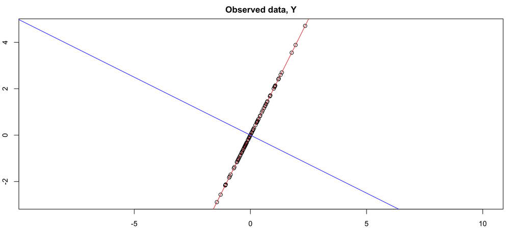

```r
par(mfrow=c(1,1))
par(mar=c(2,2,2,2))
plot(Y, main = "Observed data, Y", asp = 1)
abline(a=0,b=O[2]/O[1],col="red")
abline(a=0,b=-O[1]/O[2],col="blue")
```

- Now, consider a more realistic scenario. Assume that we only observe $\Yv$ and we don't know $\Ov$ and $\{X_t\}_{t=1}^T$.
- Given $\Yv$, how can we estimate $\Ov$, $\sig^2$, and $\{X_t\}_{t=1}^T$?
- **Idea:** We have: $\Sigv :=$ $ \Cov(Y_t) = $ $\Eb(X_t^2$ $\Ov\Ov^\top) = $ $\Ov$ $[\sig^2]$ $\Ov^\top$
- Comparing with the eigendecomposition of $\Sigv$, we conclude that $\sig^2$ must the non-zero eigenvalue of $\Sigv$ and $\Ov$ must be the corresponding eigenvector.
- We can first estimate $\Sigv$ by the sample covariance matrix $\Sigvh$
- Then, consider the eigendecomposition $\Sigvh = e(1) \lam_1 e(1)^\top$
- Finally, $\sigh^2 = \lam_1$ and $\Ovh=e(1)$.
- We also need to estimate $\Xv= (X_1,\dots,X_T)^\top$.
- Note that: $\Yv\,\Ov $ $= $ $\Xv$ $\Ov^\top$ $\Ov = $ $\Xv$ $\|\Ov\|^2$ $ = \Xv$
- Therefore, $\Xvh $ $= \Yv$ $\Ovh =$ $ \Yv$ $e(1)$.
- However, note that $\Yv =$ $ \Xv$ $\Ov^\top = $ $(-\Xv)$ $(-\Ov)^\top$
- Thus, we cannot be completely sure about the estimated $\Xvh$ and $\Ovh$, since both pairs $(\Xv, \Ov)$ and $(-\Xv, -\Ov)$ would generate the same observations $\Yv$.
- In other words, given only $\Yv$, we cannot distinguish between $(\Xv, \Ov)$ or $(-\Xv, -\Ov)$. Either pair could have generated the observations $\Yv$.
- This is another example of the **parameter identification issue** which we have already encountered when studying vector error correction models.
- In the previous simulated example, let us see if we can "recover" $\Xv$ and $\Ov$ from $\Yv$ by using the eigendecomposition of the sample covariance matrix of $\Yv$
- First, we find the sample covariance matrix using R's `var()` function

```r
Sig_Y= var(Y)
Sig_Y
```

A matrix: 2 × 2 of type dbl

| 0.4868006 | 0.9736013 |
| --- | --- |
| 0.9736013 | 1.9472026 |

- Then, we find the eigendecomposition of the covariance matrix using R's `eigen()` function

```r
EigenDecomp = eigen(Sig_Y,TRUE)
print(EigenDecomp$values)
```

```
[1] 2.434003 0.000000
```

```r
print(EigenDecomp$vectors)
```

```
          [,1]       [,2]
[1,] 0.4472136 -0.8944272
[2,] 0.8944272  0.4472136
```

- The eigenvalue gives the estimate of $\sig^2$ (recall that the true value was $3$)

```r
sig^2
EigenDecomp$values[1]
```

3

2.43400324791636

- The eigenvector is an estimate of $\Ov$

```r
Ohat = matrix(EigenDecomp$vectors[,1], ncol = 1)
print(O)
print(Ohat)
```

```
           [,1]
[1,] -0.4472136
[2,] -0.8944272
          [,1]
[1,] 0.4472136
[2,] 0.8944272
```

- And $\Xv$ is estimated by $Y \Ovh$

```r
Xhat = Y%*%Ohat
print(head(X))
print(head(Xhat))
```

```
           [,1]
[1,]  0.3705939
[2,]  0.8307923
[3,]  0.1521238
[4,]  0.7687855
[5,] -0.6284537
[6,]  0.2124777
           [,1]
[1,] -0.3705939
[2,] -0.8307923
[3,] -0.1521238
[4,] -0.7687855
[5,]  0.6284537
[6,] -0.2124777
```

- Note that we have encountered the identifiability issue! Instead of the true values of $\Ov$ and $\Xv$, we recovered $-\Ov$ and $-\Xv$
- Next, let us assume a higher dimensional scenario, where instead of only one latent factor $\{X_{t}\}$, we have two factors $\{X_{t,1}\}$ and $\{X_{t,2}\}$

\begin{align*} \Yv = \begin{pmatrix} Y_{1,1} & \dots & Y_{1,k}\\ Y_{2,1} & \dots & Y_{2,k}\\ \vdots & &\\ Y_{T,1} & \dots & Y_{T,k} \end{pmatrix} = \begin{pmatrix} X_{1,1} & X_{1,2}\\ X_{2,1} & X_{2,2}\\ \vdots&\\ X_{T,1} & X_{T,2} \end{pmatrix} \begin{pmatrix} O_{1,1} & O_{2,1}\\ \vdots&\vdots\\ O_{1,k} & O_{2,k} \end{pmatrix}^\top =: \Xv\,\Ov^\top, \end{align*}

- $\{\Xv_t:=$ $(X_{t,1},$ $X_{t,2})$ $\}_{t=1}^T$ are weak WN$\Bigg($ $\begin{bmatrix}0\\0\end{bmatrix},$ $\begin{bmatrix}\sig_1^2 & 0\\0 &\sig_2^2\end{bmatrix}$ $\Bigg)$
- $\Ov$ is a constant matrix such that $\Ov^\top\Ov=I= \begin{pmatrix} 1 & 0\\ 0 &1 \end{pmatrix}$.
- In this scenario, the observations $\Yv_t = \Xv_t\,\Ov^\top$ all lie in a plane in $\Rb^k$.
- Given $\Yv$, what is the best estimate of $\Ov$, $\sig_1^2$, $\sig_2^2$, and $\Xv$?
- Similar to the previous case, note that

\begin{align*} \Sigv = \Cov(Y_t) = \Cov(X_t\,\Ov^\top) = \Eb\left(\Ov\,X_t^\top\,X_t\,\Ov^\top\right) = \Ov \begin{pmatrix} \sig_1^2 & 0\\ 0 &\sig_2^2 \end{pmatrix} \Ov^\top. \end{align*}

- Also, $\Yv$ $\Ov$ $ = \Xv$ $\Ov^\top$ $\Ov $ $= \Xv$ $ I $ $= \Xv.$
- Therefore, we consider the eigendecompostion of the sample covariance matrix $\Sigvh$,

\begin{align*} \Sigvh = [e(1),e(2)] \begin{pmatrix} \lam_1 & 0\\ 0 &\lam_2 \end{pmatrix} [e(1),e(2)]^\top. \end{align*}

- We then estimate $\sigh_1^2 = \lam_1$, $\sigh_2^2 = \lam_2$, $\Ovh = [e(1),e(2)]$, and $\Xvh = \Yv [e(1),e(2)]$.
- The parameter identification problem is still present in this case, in even more complicated form that the case of one factor.
- Indeed, for any matrix $A$ such that $A\,A^\top=I$ (such matrices are called orthonormal), we have \begin{align*} \Yv = \Xv\,\Ov^\top = \Xv\,A\,A^\top\Ov^\top = (\Xv\,A)\,(\Ov\,A)^\top. \end{align*}
- Therefore, by only knowing $\Yv$, we cannot say if $(\Xv,\Ov)$ has generated $\Yv$ or $(\Xv\,A,\Ov\,A)$ (for any orthonormal matrix $A$).
- Let us simulate an example with two latent factors, and then use eigendecomposition to recover the model parameter and the latent factors.
- To simulate the sample, we used the `mvnorm()` function of `MASS` package to generate multivariate normal random variables, and `randortho()` function of `pracma` package to generate a random orthonormal matrix $\Ov$

```r
T=500
k = 5
m=2
sigx2 = diag(m:1)
library(MASS)
set.seed(99)
X = mvrnorm(T, rep(0, m), sigx2)
print(head(X))
```

```
           [,1]       [,2]
[1,] -0.3025887 -0.2362795
[2,] -0.6783390 -1.1274360
[3,] -0.1242085 -1.5368580
[4,] -0.6277107 -0.2297752
[5,]  0.5131303  2.0363622
[6,] -0.1734873  1.2722479
```

```r
library(pracma)
set.seed(99)
O = randortho(k,type = "orthonormal")[,1:m]
print(O)
```

```
           [,1]       [,2]
[1,]  0.3548311 -0.8128315
[2,]  0.1642103  0.4385305
[3,]  0.2711271  0.1359247
[4,] -0.1804999  0.2465324
[5,]  0.8608367  0.2602734
```

- It is not possible to visualize observations in a 5 dimensional space. But, if we could see in 5 dimensions, then we would notice that the data is in a 2-dimensional plane.

```r
Y = X %*% t(O)
print(head(Y))
```

```
            [,1]       [,2]       [,3]         [,4]       [,5]
[1,]  0.08468755 -0.1533039 -0.1141562 -0.003633322 -0.3219767
[2,]  0.67571971 -0.6058053 -0.3371625 -0.155509395 -0.8773807
[3,]  1.20513357 -0.6943554 -0.2425732 -0.356465740 -0.5069265
[4,] -0.03596278 -0.2038400 -0.2014215  0.056654714 -0.6001607
[5,] -1.47314477  0.9772682  0.4159154  0.409409370  0.9717322
[6,] -1.09568181  0.5294310  0.1258928  0.344964823  0.1817880
```

- Next, we assume that we don't know the true values of $\sig_1^2$, $\sig_2^2$, $\Ov$, $\{X_{t,1}\}$ and $\{X_{t,2}\}$.
- We try to use eigendecomposing of the sample covariance matrix of $\Yv$ to estimate the unknowns

```r
CovMat= var(Y)
EigenDecomp = eigen(CovMat,TRUE)
options(digits=3)
print(EigenDecomp$values)
print(EigenDecomp$vectors)
```

```
[1]  2.10e+00  1.04e+00  1.78e-15 -8.37e-17 -1.69e-16
       [,1]   [,2]    [,3]   [,4]    [,5]
[1,] -0.277  0.843 -0.4620  0.000  0.0000
[2,] -0.205 -0.421 -0.6455  0.378  0.4703
[3,] -0.283 -0.110 -0.0309  0.596 -0.7428
[4,]  0.157 -0.262 -0.5724 -0.595 -0.4744
[5,] -0.881 -0.178  0.2033 -0.385  0.0448
```

```r
sigxhat2 = diag(EigenDecomp$values[1:m])
print(sigx2)
print(sigxhat2)
```

```
     [,1] [,2]
[1,]    2    0
[2,]    0    1
     [,1] [,2]
[1,]  2.1 0.00
[2,]  0.0 1.04
```

```r
Ohat = EigenDecomp$vectors[,1:m]
print(O)
print(Ohat)
```

```
       [,1]   [,2]
[1,]  0.355 -0.813
[2,]  0.164  0.439
[3,]  0.271  0.136
[4,] -0.180  0.247
[5,]  0.861  0.260
       [,1]   [,2]
[1,] -0.277  0.843
[2,] -0.205 -0.421
[3,] -0.283 -0.110
[4,]  0.157 -0.262
[5,] -0.881 -0.178
```

```r
Xhat = Y%*%Ohat
print(head(X))
print(head(Xhat))
```

```
       [,1]   [,2]
[1,] -0.303 -0.236
[2,] -0.678 -1.127
[3,] -0.124 -1.537
[4,] -0.628 -0.230
[5,]  0.513  2.036
[6,] -0.173  1.272
        [,1]   [,2]
[1,]  0.3234  0.207
[2,]  0.7811  1.059
[3,]  0.2679  1.518
[4,]  0.6465  0.170
[5,] -0.7020 -1.979
[6,]  0.0533 -1.283
```

- The parameter identification issue is more evident in this example. The estimated values of $\Ov$ and $\Xv$ do not look like the original parameters.
- However, they both generate the same values of $\Yv$, hence, if we only observe the values of $\Yv$, we cannot distinguish between the actual and estimated values of $\Ov$ and $\Xv$

# 5. PCA

- PCA is similar to the scenario that we studied above.
- Consider an i.i.d. sample $\{\Yv_t := (Y_{t,1},\dots,Y_{t,k})\}_{t=1}^T$. The sample size (number of observations) is $T$, the dimension of each observation is $k$. The observations are independent and identically distributed.
- Our goal is to reduce the dimension $k$ of the data in the following sense.
- We would like to find a fewer dimensional random sample, say $\{\Xv_t := (X_{t,1},\dots,X_{t,m})\}_{t=1}^T$, where $m\ll k$, such that most of the variations in $\{\Yv_t\}$ is explained by $\{\Xv_t\}$.
- We only consider **normed linear combinations** as factors.
- These are the factors of the form $\displaystyle X_t = \Yv_t\,\alv = \sum_{i=1}^k \al_i\,Y_{t,i}$
- Here, $\alv=(\al_1,\dots,\al_k)^\top$ is a constant unit vector, i.e. $\|\alv\|^2 = 1$.
- The **first principal axis**, denoted by $\Ov_1$, indicates the direction in $\Rb^k$ where $\{\Yv_t\}$ has the most variation.
- $\Ov_1$ is the maximizer of the following problem

\begin{align*} \Var(\Yv_t\,\Ov_1) = \max\{\Var(\Yv_t\,\alv\,:\,\|\al\|^2=1\}. \end{align*}

- The **first principal components**, denoted by $\{X_{t,1}\}_{t=1}^T$, are the projection of observations $\{\Yv_t\}$ in the direction of $\Ov_1$. In particular, $\Xv_{t,1} = \Yv_{t,1}\Ov_1$.
- The **second principal axis**, denoted by $\Ov_2$, indicates the direction in $\Rb^k$ orthogonal to $\Ov_1$, where $\{\Yv_t\}$ has the most variation.
- $\Ov_2$ is the maximizer of the following problem \begin{align*} \Var(\Yv_t\,\Ov_2) = \max\{\Var(\Yv_t\,\alv\,:\,\|\al\|^2=1, \alv\cdot\Ov_1=0\}. \end{align*}
- The **second principal components**, denoted by $\{X_{t,2}\}_{t=1}^T$, are the projection of observations $\{\Yv_t\}$ in the direction of $\Ov_2$. In particular, $X_{t,2} = \Yv_t\,\Ov_2$.
- In general, the **i-th principal axis**, denoted by $\Ov_i$, indicates the direction in $\Rb^k$ that is orthogonal to all the previous principal axes (i.e. $\Ov_1, \dots \Ov_{i-1}$) and where $\{\Yv_t\}$ has the most variation.
- $\Ov_i$ is the maximizer of the following problem

\begin{align*} \Var(\Yv_t\,\Ov_i) = \max\{\Var(\Yv_t\,\alv\,:\,\|\al\|^2=1, \alv\cdot\Ov_1=\dots = \alv\cdot\Ov_{i-1}=0\}. \end{align*}

- The **i-th principal components**, denoted by $\{X_{t,i}\}_{t=1}^T$, are the projection of observations $\{\Yv_t\}$ in the direction of $\Ov_i$. In particular, $X_{t,i} = \Yv_t\,\Ov_i$.
- It seems that we have to solve a maximization problem to find each principal components and axis.
- The optimization problems are not hard to solve and can be solved simultaneously.
- Indeed, as it turns out, the eigendecomposition of the covariance matrix $\Sigv = \Cov(\Yv_t)$ yields the principal components and exes.
- Consider the eigendecomposition of $\Sigv$:

\begin{align*} \Sigv = \Ev\,\Lamv\,E^\top = [e(1),\dots, e(k)] \text{diag}(\lam_1,\dots,\lam_k) [e(1),\dots, e(k)]^\top \end{align*}

- Then, $\Ov_i =$ $ e(i)$, $\Var(\Yv_t$ $\Ov_i) =$ $ \lam_i$, and $\Cov(X_{t,i},$ $ X_{t,j}) =$ $ Cov(\Yv_t$ $\Ov_i,$ $\Yv_t$ $\Ov_j)$ $ = 0$ for $i\ne j$.
- Using these results, we may interpret the eigenvalues of $\Sigv$ as follows.
- $\lam_i$ measures the variation of $\{\Yv_t\}$ that is explained by the i-th principal component $\{X_{t,i}\}$.
- $\lam_1 + \dots + \lam_k$ measures the total variation of $\{\Yv_t\}$ that is explained by all the principal components.
- $\displaystyle \frac{\lam_i}{\lam_1 + \dots + \lam_k}$ is the proportion of the explainable variation of $\{\Yv_t\}$ that is explained by $X_{t,i}$.
- $\displaystyle \frac{\lam_1 + \dots + \lam_i}{\lam_1 + \dots + \lam_k}$ is the proportion of the explainable variation of $\{\Yv_t\}$ that is explained by the first $i$ principal component $\{X_{t,1}\}, \dots, \{X_{t,i}\}$.
- In many practical scenarios, most of the variations (say 95\%) is explained by only a few principal components. In these scenarios, we can use those first few principal components to analyze the variations in (the higher dimensional) $\{\Yv_t\}$.
- To illustrate PCA, let us consider daily returns of 8 equity funds which include stocks in each of the following geographical regions or business sector: Eastern Europe, South America, China, India, Energy, Mining, Gold, Water.
- Our goal is to find a few factors that explains the returns of these 8 returns.

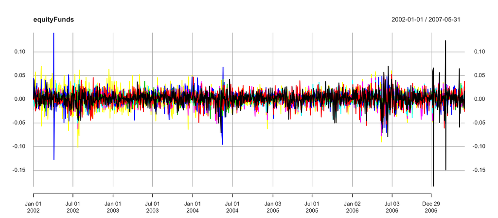

```r
library(xts)
dat = read.csv("equityFunds.csv")
equityFunds = xts(dat[,2:9], order.by = as.Date(dat[,1]))
plot(equityFunds)
```

- Let us visualize the (contemporaneous) correlation matrix of returns

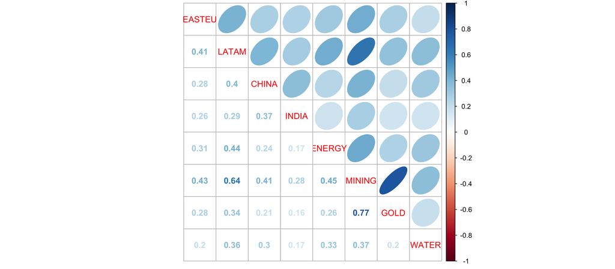

```r
library(corrplot)
corrplot.mixed(cor(equityFunds),upper="ellipse")
```

- We can perform PCA by using R's `prcomp()` function.
- The first PC explains 46.7% of the variations. The second PC, explains an additional 16.76%. So, the first two explain 63.46% of the variations.
- To explain at least 95%, we need 6 PCs.

```r
equityFunds_pca = prcomp(equityFunds)
summary(equityFunds_pca)
names(equityFunds_pca)
```

```
Importance of components:
                          PC1    PC2    PC3    PC4     PC5     PC6     PC7
Standard deviation     0.0264 0.0158 0.0132 0.0120 0.00969 0.00786 0.00647
Proportion of Variance 0.4670 0.1676 0.1165 0.0968 0.06271 0.04129 0.02797
Cumulative Proportion  0.4670 0.6346 0.7511 0.8480 0.91067 0.95196 0.97992
                           PC8
Standard deviation     0.00548
Proportion of Variance 0.02008
Cumulative Proportion  1.00000
```

1. 'sdev'

2. 'rotation'

3. 'center'

4. 'scale'

5. 'x'

- A **scree plot** is a good visualization of explanatory power of different PCs
- It is a simple bar plot of **variances** of the PCs.

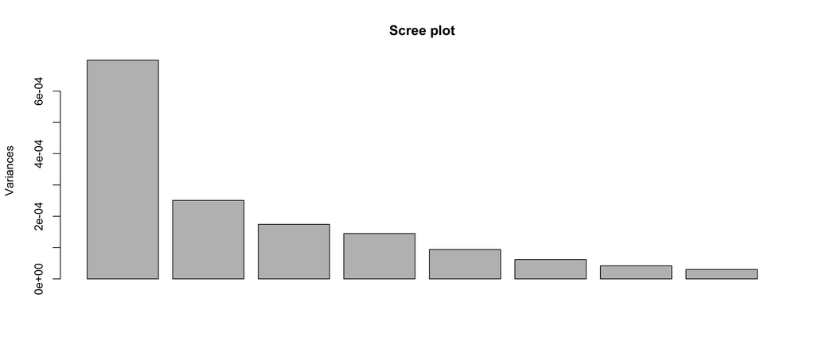

```r
plot(equityFunds_pca,main="Scree plot")
```

- Once we decided how many PC to include, we should take a look at principal axes (PA).
- Here, we decide to use 3 PCs (explaining 75% of the variations)
- the first PC represents movements where returns are changing in the same direction (all the weights PA1 have the same sign)
- In the second and third PC, movements are in different directions. In the second PC, countries move the opposite of Gold price. In the third PC, India (and possibly Gold) move against Eastern Europe, South America, and Energy.
- Note that these interpretations are the result of the data. Like any other statistical result, you should try to find the reasons behind them before using them as evidence.

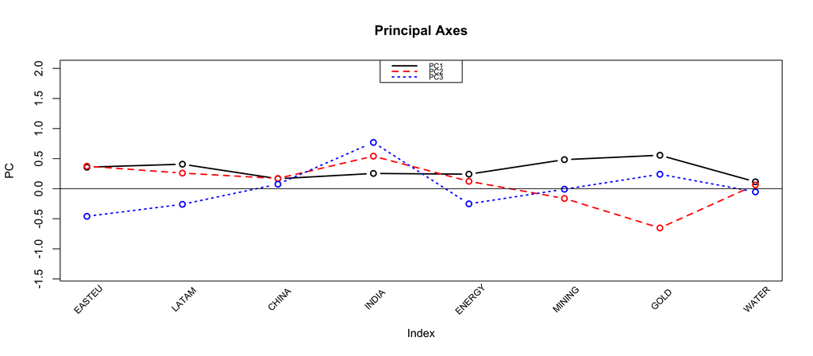

```r
plot(equityFunds_pca$rotation[,1],type="b",ylab="PC",lwd=2,ylim=c(-1.4,2),
     main="Principal Axes", xaxt="n")
lines(equityFunds_pca$rotation[,2],type="b",lty=2,lwd=2,col="red")
lines(equityFunds_pca$rotation[,3],type="b",lty=3,lwd=2,col="blue")
abline(h=0, col=1)
legend("top",c("PC1","PC2","PC3"),lty=c(1,2,3),lwd=2,cex=.65,col=c("black", "red", "blue"))
text(1:8,1.1*par("usr")[3],names(equityFunds),srt = 45,cex=.8,pos = 1, xpd = TRUE)
```

- Let us consider a higher dimensional problem. Consider the 30 stocks in Dow Jones index over 10 years.

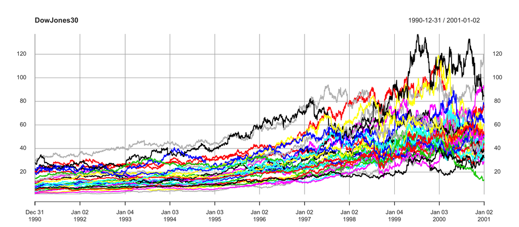

```r
dat = read.csv("DowJones30.csv")
DowJones30 = xts(dat[,2:31], order.by = as.Date(dat[,1]))
plot(DowJones30)
```

- The correlation plots (for the first 10 stocks and all the stocks) are as follows.

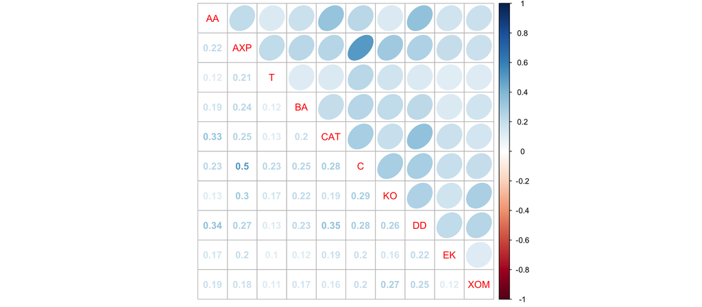

```r
library(corrplot)
DJrtn = na.omit(diff(log(DowJones30)))
corrplot.mixed(cor(DJrtn[,1:10]),upper="ellipse")
```

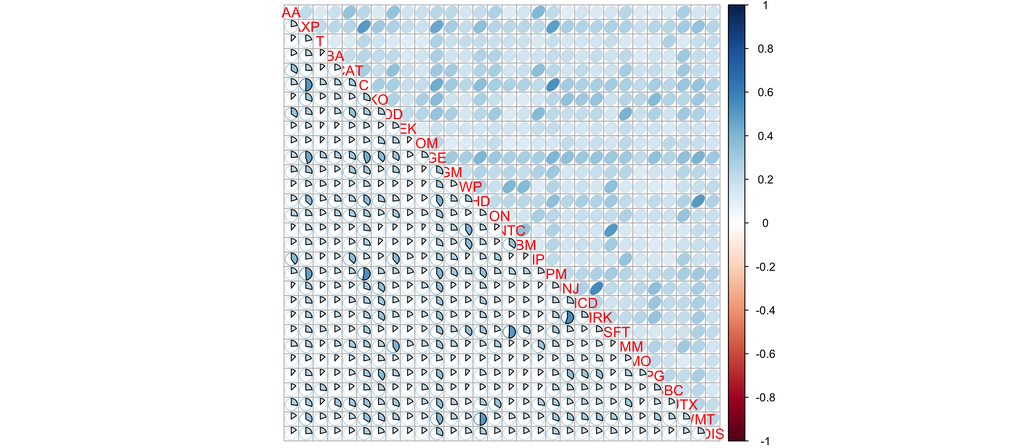

```r
corrplot.mixed(cor(DJrtn),upper="ellipse", lower="pie")
```

- We need 26 PC to explain 95%!
- However, we also see that the first PC has a significantly more explanatory power than the rest.

```r
DJrtn_pca = prcomp(DJrtn)
summary(DJrtn_pca)
```

```
Importance of components:
                          PC1    PC2    PC3    PC4    PC5    PC6    PC7    PC8
Standard deviation     0.0547 0.0301 0.0246 0.0221 0.0213 0.0203 0.0195 0.0190
Proportion of Variance 0.2558 0.0772 0.0516 0.0418 0.0386 0.0351 0.0326 0.0309
Cumulative Proportion  0.2558 0.3330 0.3846 0.4264 0.4650 0.5002 0.5328 0.5637
                          PC9   PC10   PC11   PC12   PC13   PC14   PC15   PC16
Standard deviation     0.0183 0.0178 0.0175 0.0174 0.0171 0.0170 0.0168 0.0163
Proportion of Variance 0.0288 0.0271 0.0261 0.0259 0.0251 0.0248 0.0241 0.0228
Cumulative Proportion  0.5925 0.6196 0.6456 0.6715 0.6966 0.7214 0.7455 0.7683
                         PC17   PC18   PC19   PC20   PC21   PC22   PC23   PC24
Standard deviation     0.0159 0.0158 0.0153 0.0153 0.0152 0.0144 0.0141 0.0139
Proportion of Variance 0.0215 0.0213 0.0201 0.0199 0.0197 0.0178 0.0170 0.0165
Cumulative Proportion  0.7898 0.8111 0.8312 0.8511 0.8707 0.8885 0.9055 0.9220
                         PC25   PC26   PC27   PC28   PC29   PC30
Standard deviation     0.0138 0.0135 0.0123 0.0119 0.0113 0.0109
Proportion of Variance 0.0163 0.0155 0.0129 0.0121 0.0109 0.0102
Cumulative Proportion  0.9384 0.9539 0.9668 0.9789 0.9898 1.0000
```

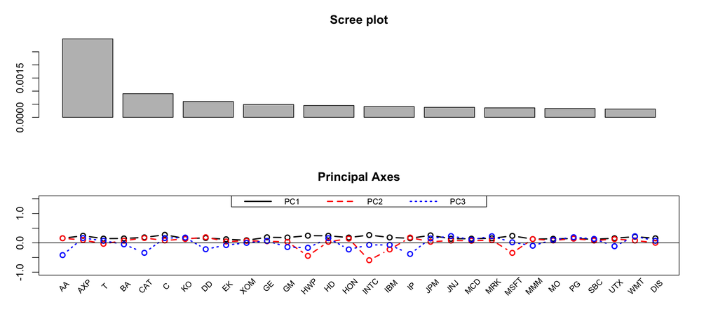

```r
par(mfrow=c(2,1));par(mar=c(3,3,3,3))
plot(DJrtn_pca,main="Scree plot")
plot(DJrtn_pca$rotation[,1],type="b",ylab="PC",lwd=2,ylim=c(-1,1.5),
     main="Principal Axes", xaxt="n")
lines(DJrtn_pca$rotation[,2],type="b",lty=2,lwd=2,col="red")
lines(DJrtn_pca$rotation[,3],type="b",lty=3,lwd=2,col="blue")
abline(h=0, col=1)
legend("top",c("PC1","PC2","PC3"),
       lty=c(1,2,3),lwd=2,cex=.8,
       col=c("black", "red", "blue"),
       ncol = 3)
text(1:30,1.1*par("usr")[3],names(DJrtn),srt = 45,cex=.8,pos = 1, xpd = TRUE)
```

- As you can see, a simple PCA is not sufficient for explaining asset returns.
- In Lecture 16 we discuss factor models, which are dimension reduction model specifically designed for asset returns.